# Fundamentos de Programación en R

Economía aplicada y ciencia de datos para el bien público

Mtro. René Rosado González

### Operaciones aritméticas básicas

| Operador | Operación | Ejemplo | Resultado |
| --- | --- | --- | --- |
| `+` | Suma | `5 + 5` | `10` |
| `-` | Resta | `5 - 5` | `0` |
| `*` | Multiplicación | `5 * 5` | `25` |
| `/` | División | `5 /5` | `1` |
| `^` | Potencia | `5 ^ 5` | `3125` |
| `%%` | Módulo | `5 %% 3` | `2` |

### Operaciones relacionales

| Operador | Comparación | Ejemplo | Resultado |
| --- | --- | --- | --- |
| `<` | Menor que | `5 < 3` | `FALSE` |
| `<=` | Menor o igual que | `5 <= 3` | `FALSE` |
| `>` | Mayor que | `5 > 3` | `TRUE` |
| `>=` | Mayor o igual que | `5 >= 3` | `TRUE` |
| `==` | Exactamente igual que | `5 == 3` | `FALSE` |
| `!=` | Distinto que | `5 != 3` | `TRUE` |

### Operadores lógicos

| Operador | Comparación | Ejemplo | Resultado |
| --- | --- | --- | --- |
| `x \| y` | `x` ó `y` son verdaderos | `TRUE \| FALSE` | `TRUE` |
| `x & y` | `x` y `y` son verdaderos | `TRUE & FALSE` | `FALSE` |
| `!x` | `x` no es verdadero (negación) | `!TRUE` | `FALSE` |
| `isTRUE(x)` | `x` es verdadero (afirmación) | `isTRUE(TRUE)` | `TRUE` |

### Jerarquía de operaciones

| Orden | Operadores |
| --- | --- |
| 1 | `^` |
| 2 | `*` |
| 3 | `/` |
| 4 | `+` `-` |
| 5 | `<` `>` `<=` `>=` `==` `!=` |
| 6 | `!` |
| 7 | `&` |
| 9 | `\|` |
| 10 | `<-` `=` |

### Asignación de variables

```r
# Asignación de variables
x <- 5

# Imprimir variables
print(x)
```

```
## [1] 5
```

```r
# Asignación de variables
y <- 2

# Imprimir variables
print(y)
```

```
## [1] 2
```

### Operaciones con variables

```r
# Asignación de variables
print(x + y)
```

```
## [1] 7
```

```r
# Asignación de variables
z <- x + y
print(z)
```

```
## [1] 7
```

### Tipos de datos

```r
# Decimales
decimales <- 1.1
# Revisar la clase
class(decimales)
```

```
## [1] "numeric"
```

```r
# Enteros
entero <- 1
# Revisar la clase
class(entero)
```

```
## [1] "numeric"
```

```r
# Booleanos
booleano <- TRUE
# Revisar la clase
class(booleano)
```

```
## [1] "logical"
```

```r
# Texto
texto <- '1'
# Revisar la clase
class(texto)
```

```
## [1] "character"
```

### Estructuras de datos

| Dimensiones | Homogéneas | Heterogéneas |
| --- | --- | --- |
| 1 | Vector | Lista |
| 2 | Matriz | Data frame |
| n | Array |  |

##### Vectores

Son una colección de uno o más datos del mismo tipo y son la estructura de datos elemental en R.

```r
# Tododos los datos son expresados como vectores
is.vector(1)
```

```
## [1] TRUE
```

Tienen tres propiedades:

- **Atómicos**, sólo pueden contener datos de un sólo tipo, no es posible mezclar datos de tipos diferentes dentro de ellos.
- **Largo**. Es el número de elementos que contiene un vector. El largo es la única dimensión que tiene esta estructura de datos.
- **Atributos**. Los vectores pueden tener metadatos de muchos tipos, los cuales describen características de los datos que contienen.

Cuando una estructura únicamente puede contener datos de un sólo tipo, como es el caso de los vectores, decimos que es **homogénea**, pero no implica que necesariamente sea **atómica**.

```r
# Numéricos
vector_numerico <- c(1, 1.5, 2, 2.5, 3)
# Revisar la clase
class(vector_numerico)
```

```
## [1] "numeric"
```

```r
# Revisar la longitud
length(vector_numerico)
```

```
## [1] 5
```

```r
# Caracteres
vector_caracter <- c("a", "b", "c")
# Revisar la clase
class(vector_caracter)
```

```
## [1] "character"
```

```r
# Revisar la longitud
length(vector_caracter)
```

```
## [1] 3
```

```r
# Booleanos
vector_booleano <- c(TRUE, FALSE)
# Revisar la clase
class(vector_booleano)
```

```
## [1] "logical"
```

```r
# Revisar la longitud
length(vector_booleano)
```

```
## [1] 2
```

```r
# Mixtos
vector_mixto <- c(vector_numerico, vector_caracter, vector_booleano)
vector_mixto
```

```
##  [1] "1"     "1.5"   "2"     "2.5"   "3"     "a"     "b"     "c"     "TRUE"
## [10] "FALSE"
```

```r
# Revisar la clase
class(vector_mixto)
```

```
## [1] "character"
```

```r
# Revisar la longitud
length(vector_mixto)
```

```
## [1] 10
```

#### Indexado vectorial

Los índices permiten referencial la posición de un elemento dentro de los arreglos. En el caso de R, la Indexado comienza en `1`.

```r
# Definimos un vector
mi_vector <- c(1, 2, 3, 4, 5)
# Primer posición
mi_vector[1]
```

```
## [1] 1
```

```r
# Última posición
mi_vector[length(mi_vector)]
```

```
## [1] 5
```

```r
# Exclusiones
mi_vector[-1]
```

```
## [1] 2 3 4 5
```

```r
# Indexado múltiple (no tiene que ser un orden)
mi_vector[c(1, 4, 3, 2,5)]
```

```
## [1] 1 4 3 2 5
```

Además del índice, podemos utilizar otro atributo de los vectores para identificar las posiciones de sus elementos.

```r
# Revisamos los nombres de los elementos
names(mi_vector)
```

[output not shown]

```r
# Asignamos nombres nuevos
names(mi_vector) <- c(LETTERS[1:5])
# Nuetro vector luce así
mi_vector
```

```
## A B C D E
## 1 2 3 4 5
```

```r
# Atributos
attributes(mi_vector)
```

```
## $names
## [1] "A" "B" "C" "D" "E"
```

```r
# Filtramos el elementro
mi_vector[c('E','C','A')]
```

```
## E C A
## 5 3 1
```

#### Vectorización de operaciones

Existen algunas operaciones al aplicarlas a un vector, se aplican a cada uno de sus elementos. A este proceso le llama **vectorización**.

```r
# Suma
mi_vector + 2
```

```
## A B C D E
## 3 4 5 6 7
```

```r
# Resta
mi_vector - 2
```

```
##  A  B  C  D  E
## -1  0  1  2  3
```

```r
# Multiplicación
mi_vector * 2
```

```
##  A  B  C  D  E
##  2  4  6  8 10
```

```r
# Divisioón
mi_vector / 2
```

```
##   A   B   C   D   E
## 0.5 1.0 1.5 2.0 2.5
```

```r
# Módulo
mi_vector %% 2
```

```
## A B C D E
## 1 0 1 0 1
```

```r
# Mayor (igual) que
mi_vector > 2
```

```
##     A     B     C     D     E
## FALSE FALSE  TRUE  TRUE  TRUE
```

```r
# Menor (igual) que
mi_vector < 2
```

```
##     A     B     C     D     E
##  TRUE FALSE FALSE FALSE FALSE
```

```r
# Igual (distinto) que
mi_vector == 2
```

```
##     A     B     C     D     E
## FALSE  TRUE FALSE FALSE FALSE
```

Si observas con cuidado, al aplicar operaciones relacionales obtenemos vectores lógicos. Podemos utilizar estos resultados para filtrar vectores.

```r
# Una operación relacional
mi_vector[mi_vector > 2]
```

```
## C D E
## 3 4 5
```

```r
# Dos (o más) operaciones relacional
mi_vector[(mi_vector > 2) & (mi_vector < 4)]
```

```
## C
## 3
```

##### Matrices y arreglos

Las matrices son un conjunto de **vectores ordenados**. Al igual que un vector, únicamente pueden contener datos de un sólo tipo, pero además de largo, tienen más dimensiones. En un sentido estricto, las matrices son una caso especial de un `array`, que se distingue por tener **específicamente dos dimensiones**. Los `arrays`, por su parte, pueden tener un número arbitrario de dimensiones, pero su uso no es común en el análisis de datos.

```r
# Contruir una matriz de 3 x 4
matriz <- matrix(data = 1:12, nrow = 3, ncol = 4)
matriz
```

```
##      [,1] [,2] [,3] [,4]
## [1,]    1    4    7   10
## [2,]    2    5    8   11
## [3,]    3    6    9   12
```

```r
# Revisar las atributos
attributes(matriz)
```

```
## $dim
## [1] 3 4
```

```r
# Nombres de filas y columnas
rownames(matriz) = paste('fila', 1:3, sep = '_')
colnames(matriz) = paste('col', 1:4, sep = '_')
matriz
```

```
##        col_1 col_2 col_3 col_4
## fila_1     1     4     7    10
## fila_2     2     5     8    11
## fila_3     3     6     9    12
```

```r
# Revisar la clase
is.numeric(matriz)
```

```
## [1] TRUE
```

```r
#Indexado (fila, columna)
matriz[2,1]
```

```
## [1] 2
```

```r
#Indexado (fila, columna)
matriz['fila_2','col_1']
```

```
## [1] 2
```

```r
#Indexado (fila, columna)
matriz[1:2,1:2]
```

```
##        col_1 col_2
## fila_1     1     4
## fila_2     2     5
```

```r
#Indexado todas las filas
matriz[,1]
```

```
## fila_1 fila_2 fila_3
##      1      2      3
```

```r
#Indexado todas las columnas
matriz[1,]
```

```
## col_1 col_2 col_3 col_4
##     1     4     7    10
```

```r
#Asignar valores a un elementro
matriz[2,1] = 'a'
matriz
```

```
##        col_1 col_2 col_3 col_4
## fila_1 "1"   "4"   "7"   "10"
## fila_2 "a"   "5"   "8"   "11"
## fila_3 "3"   "6"   "9"   "12"
```

```r
# Revisar la clase
is.numeric(matriz)
```

```
## [1] FALSE
```

```r
# Revisar la clase
is.character(matriz)
```

```
## [1] TRUE
```

##### Data Frames

Los data frames son un conjunto de **vectores ordenados** en formato columnar que pueden contener datos de distintos tipos.

```r
# Creamos un data.frame
df <- data.frame(
  numeros = 1:10,
  letras = letters[1:10],
  booleanos = rep(c(TRUE, FALSE), 5)
)
df
```

```
##    numeros letras booleanos
## 1        1      a      TRUE
## 2        2      b     FALSE
## 3        3      c      TRUE
## 4        4      d     FALSE
## 5        5      e      TRUE
## 6        6      f     FALSE
## 7        7      g      TRUE
## 8        8      h     FALSE
## 9        9      i      TRUE
## 10      10      j     FALSE
```

```r
# Revisamos sus atributos
attributes(df)
```

```
## $names
## [1] "numeros"   "letras"    "booleanos"
##
## $class
## [1] "data.frame"
##
## $row.names
##  [1]  1  2  3  4  5  6  7  8  9 10
```

```r
# Indexado fila, columna
df[1,1]
```

```
## [1] 1
```

```r
# Trabajar con vectores columnas
df$numeros
```

```
##  [1]  1  2  3  4  5  6  7  8  9 10
```

```r
# Indexado en vectores columnas
df$numeros[6:10]
```

```
## [1]  6  7  8  9 10
```

```r
df[6:10,1]
```

```
## [1]  6  7  8  9 10
```

##### Listas

Las listas, al igual que los vectores, son estructuras de datos unidimensionales, sólo tienen largo, pero cada uno de sus elementos puede ser de diferente tipo o incluso de diferente clase, por lo que son estructuras heterogéneas.

```r
# Crear una lista
mi_lista <- list(
  vector_numerico = vector_numerico,
  vector_caracter = vector_caracter,
  vector_booleano = vector_booleano,
  matriz = matriz,
  dataframe = df
)
mi_lista
```

```
## $vector_numerico
## [1] 1.0 1.5 2.0 2.5 3.0
##
## $vector_caracter
## [1] "a" "b" "c"
##
## $vector_booleano
## [1]  TRUE FALSE
##
## $matriz
##        col_1 col_2 col_3 col_4
## fila_1 "1"   "4"   "7"   "10"
## fila_2 "a"   "5"   "8"   "11"
## fila_3 "3"   "6"   "9"   "12"
##
## $dataframe
##    numeros letras booleanos
## 1        1      a      TRUE
## 2        2      b     FALSE
## 3        3      c      TRUE
## 4        4      d     FALSE
## 5        5      e      TRUE
## 6        6      f     FALSE
## 7        7      g      TRUE
## 8        8      h     FALSE
## 9        9      i      TRUE
## 10      10      j     FALSE
```

```r
# Indexado en listas (erroneo)
mi_lista[1]
```

```
## $vector_numerico
## [1] 1.0 1.5 2.0 2.5 3.0
```

```r
mi_lista[1][2]
```

```
## $<NA>
## NULL
```

```r
# Indexado en listas  (correcto)
mi_lista[[1]][2]
```

```
## [1] 1.5
```

```r
mi_lista$vector_numerico[2]
```

```
## [1] 1.5
```

```r
# Listas anidadas
mi_lista_anidada = list(
  lista_completa = mi_lista,
  vector_booleano = vector_booleano,
  lista_sin_df = mi_lista[1:4]
)
mi_lista_anidada
```

```
## $lista_completa
## $lista_completa$vector_numerico
## [1] 1.0 1.5 2.0 2.5 3.0
##
## $lista_completa$vector_caracter
## [1] "a" "b" "c"
##
## $lista_completa$vector_booleano
## [1]  TRUE FALSE
##
## $lista_completa$matriz
##        col_1 col_2 col_3 col_4
## fila_1 "1"   "4"   "7"   "10"
## fila_2 "a"   "5"   "8"   "11"
## fila_3 "3"   "6"   "9"   "12"
##
## $lista_completa$dataframe
##    numeros letras booleanos
## 1        1      a      TRUE
## 2        2      b     FALSE
## 3        3      c      TRUE
## 4        4      d     FALSE
## 5        5      e      TRUE
## 6        6      f     FALSE
## 7        7      g      TRUE
## 8        8      h     FALSE
## 9        9      i      TRUE
## 10      10      j     FALSE
##
##
## $vector_booleano
## [1]  TRUE FALSE
##
## $lista_sin_df
## $lista_sin_df$vector_numerico
## [1] 1.0 1.5 2.0 2.5 3.0
##
## $lista_sin_df$vector_caracter
## [1] "a" "b" "c"
##
## $lista_sin_df$vector_booleano
## [1]  TRUE FALSE
##
## $lista_sin_df$matriz
##        col_1 col_2 col_3 col_4
## fila_1 "1"   "4"   "7"   "10"
## fila_2 "a"   "5"   "8"   "11"
## fila_3 "3"   "6"   "9"   "12"
```

##### Funciones

Las funciones son objetos que nos permiten realizar prodecimientos sobre los elementos de un vector. Para saber qué hace una función, siempre puedes apoyarte utilizando la consola con un comando`?función` Prueba corriendo el siguiente comando.

```r
?mean
```

```r
mean(df$numeros)
```

```
## [1] 5.5
```

Si bien hemos estado usando funciones predeterminadas de R, podemos crear nuestras propias funciones.

```r
normalizar <- function(x){
  y = (x - min(x))/(max(x)-min(x))
  return(y)
}
# Usamos nuestra nueva función
normalizar(df$numeros)
```

```
##  [1] 0.0000000 0.1111111 0.2222222 0.3333333 0.4444444 0.5555556 0.6666667
##  [8] 0.7777778 0.8888889 1.0000000
```

##### Cíclos for

Los cíclos for nos permiten realizar procedimientos de forma iterativa sobre un rango definido de inicio a fin.

```r
# Creamos un data frame
df = expand.grid(1:5,1:5)
df
```

```
##    Var1 Var2
## 1     1    1
## 2     2    1
## 3     3    1
## 4     4    1
## 5     5    1
## 6     1    2
## 7     2    2
## 8     3    2
## 9     4    2
## 10    5    2
## 11    1    3
## 12    2    3
## 13    3    3
## 14    4    3
## 15    5    3
## 16    1    4
## 17    2    4
## 18    3    4
## 19    4    4
## 20    5    4
## 21    1    5
## 22    2    5
## 23    3    5
## 24    4    5
## 25    5    5
```

```r
# Creamos una matriz
matriz = matrix(data = paste(df$Var1,df$Var2,sep = ','), ncol = 5)
matriz
```

```
##      [,1]  [,2]  [,3]  [,4]  [,5]
## [1,] "1,1" "1,2" "1,3" "1,4" "1,5"
## [2,] "2,1" "2,2" "2,3" "2,4" "2,5"
## [3,] "3,1" "3,2" "3,3" "3,4" "3,5"
## [4,] "4,1" "4,2" "4,3" "4,4" "4,5"
## [5,] "5,1" "5,2" "5,3" "5,4" "5,5"
```

```r
# Iteramos sobre las filas
for(fila in 1:nrow(matriz)){
  print(paste0('Fila: ',fila))
  print(matriz[fila,])
}
```

```
## [1] "Fila: 1"
## [1] "1,1" "1,2" "1,3" "1,4" "1,5"
## [1] "Fila: 2"
## [1] "2,1" "2,2" "2,3" "2,4" "2,5"
## [1] "Fila: 3"
## [1] "3,1" "3,2" "3,3" "3,4" "3,5"
## [1] "Fila: 4"
## [1] "4,1" "4,2" "4,3" "4,4" "4,5"
## [1] "Fila: 5"
## [1] "5,1" "5,2" "5,3" "5,4" "5,5"
```

```r
# Iteramos sobre las columnas
for(columna in 1:ncol(matriz)){
  print(paste0('Columna: ',columna))
  print(matriz[,columna])
}
```

```
## [1] "Columna: 1"
## [1] "1,1" "2,1" "3,1" "4,1" "5,1"
## [1] "Columna: 2"
## [1] "1,2" "2,2" "3,2" "4,2" "5,2"
## [1] "Columna: 3"
## [1] "1,3" "2,3" "3,3" "4,3" "5,3"
## [1] "Columna: 4"
## [1] "1,4" "2,4" "3,4" "4,4" "5,4"
## [1] "Columna: 5"
## [1] "1,5" "2,5" "3,5" "4,5" "5,5"
```

```
## [1] "Coordenada: 1,1"
```

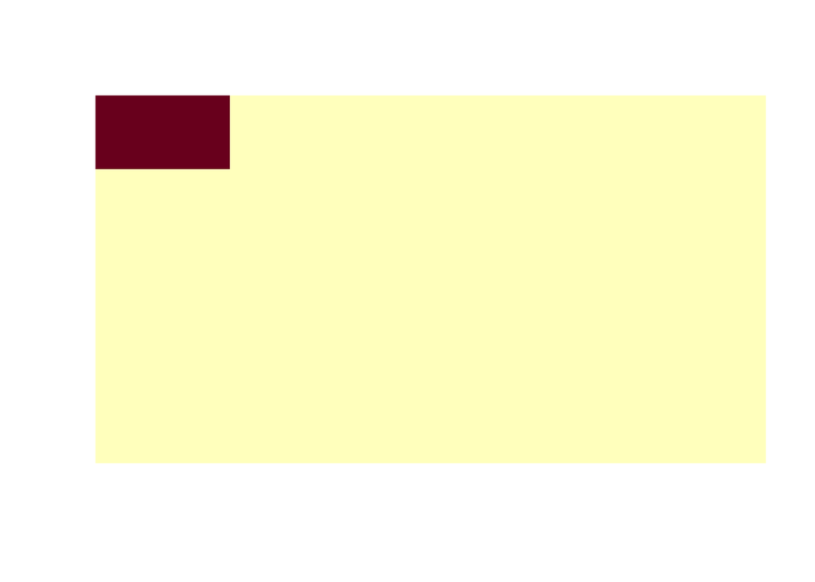

```
## [1] "Coordenada: 1,2"
```

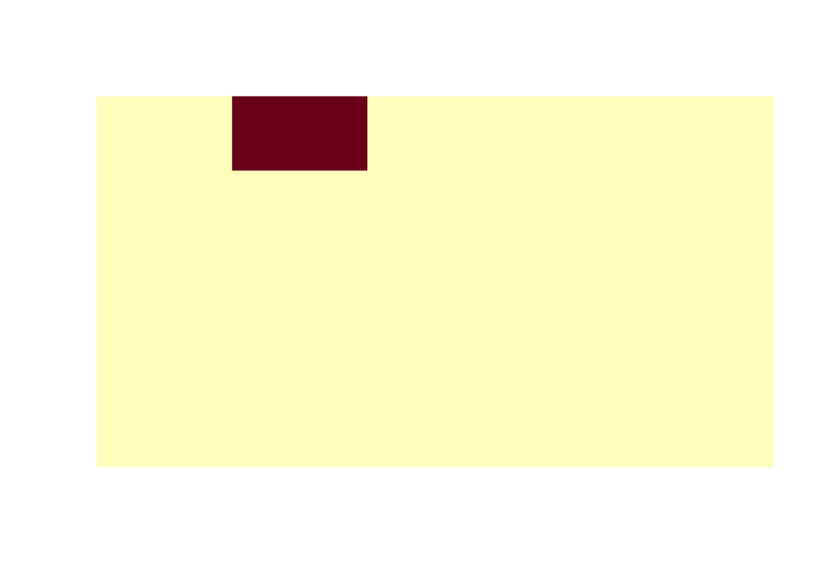

```
## [1] "Coordenada: 1,3"
```

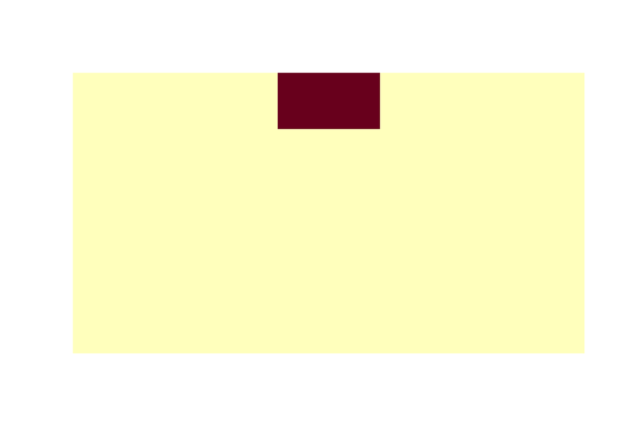

```
## [1] "Coordenada: 1,4"
```

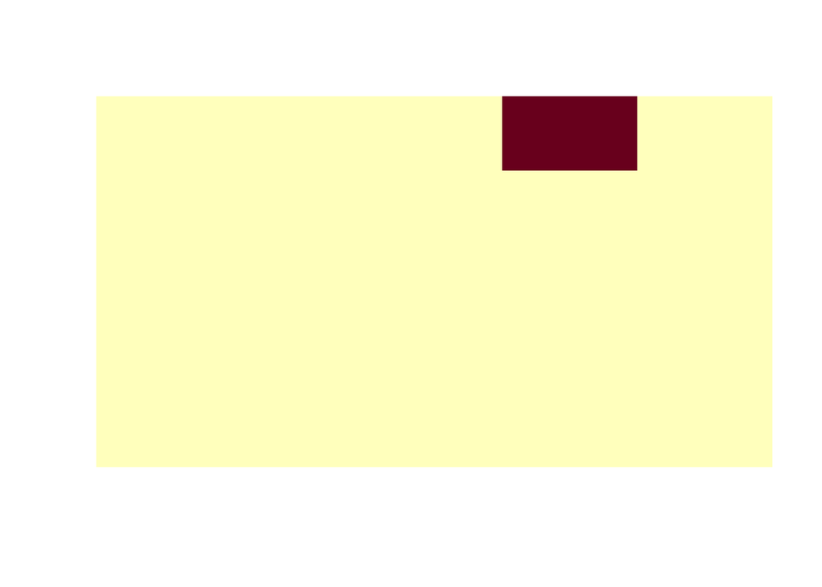

```
## [1] "Coordenada: 1,5"
```

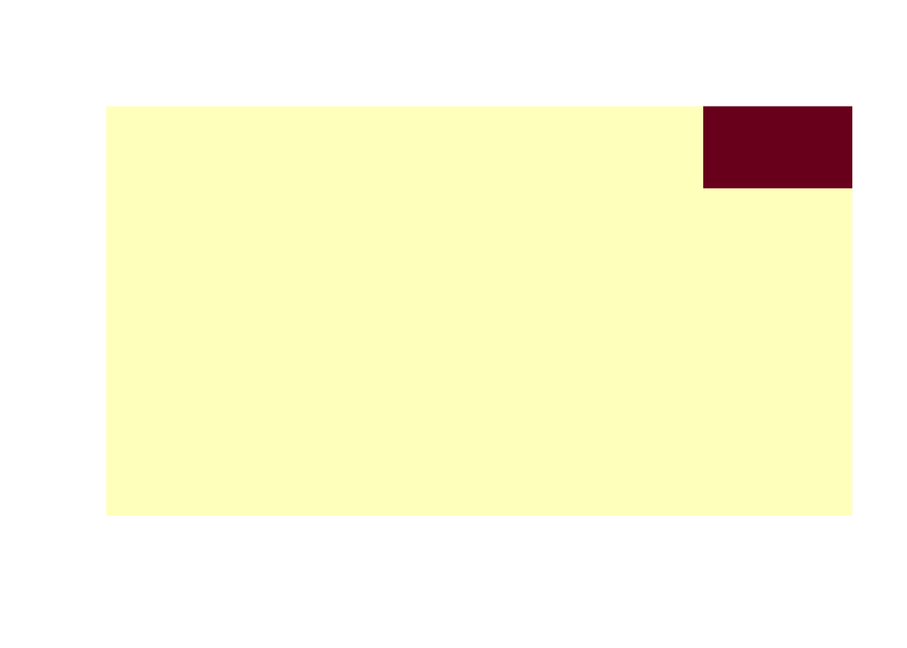

```
## [1] "Coordenada: 2,1"
```

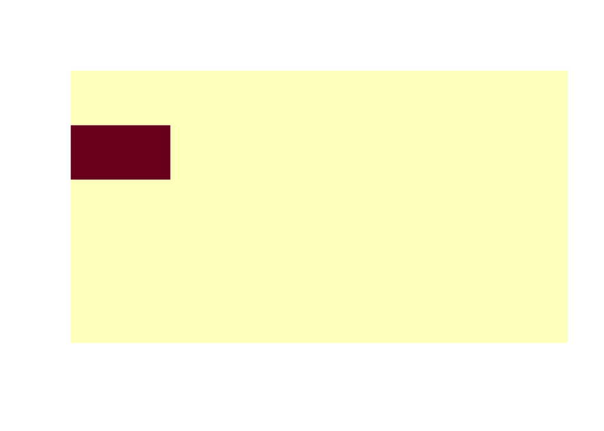

```
## [1] "Coordenada: 2,2"
```

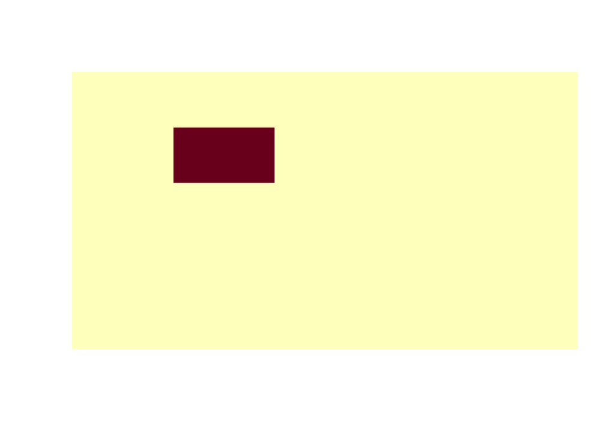

```
## [1] "Coordenada: 2,3"
```

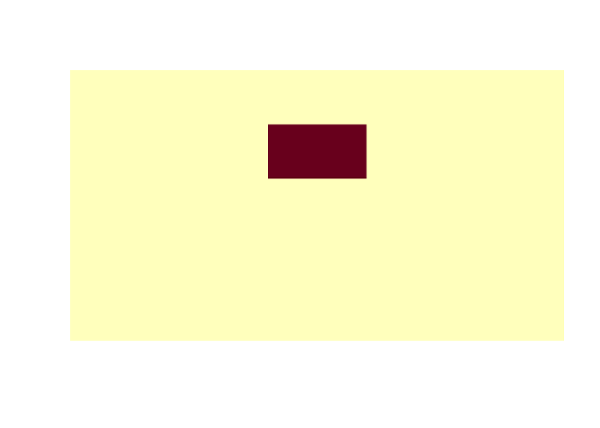

```
## [1] "Coordenada: 2,4"
```

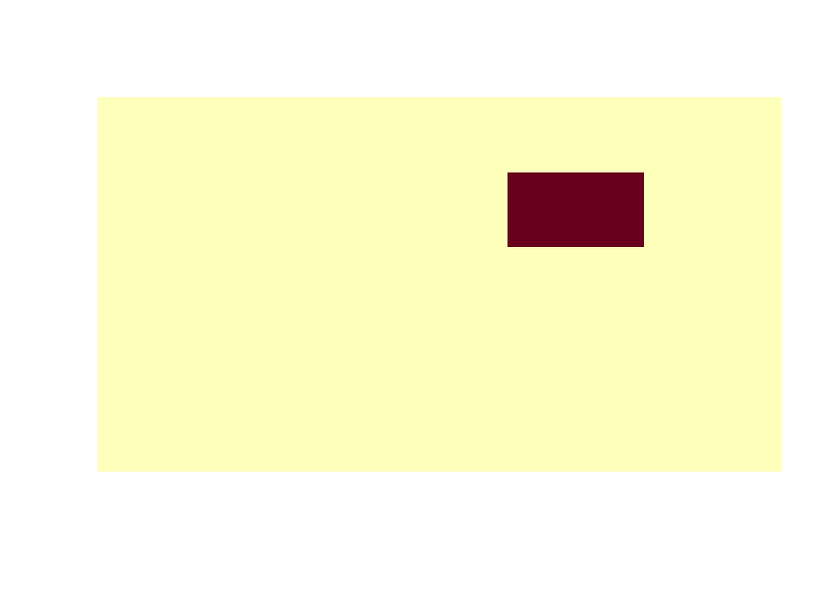

```
## [1] "Coordenada: 2,5"
```

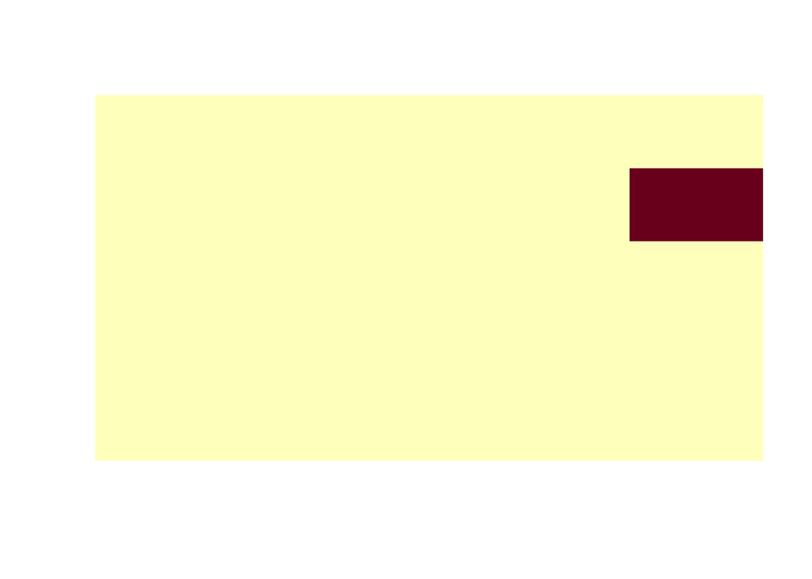

```
## [1] "Coordenada: 3,1"
```

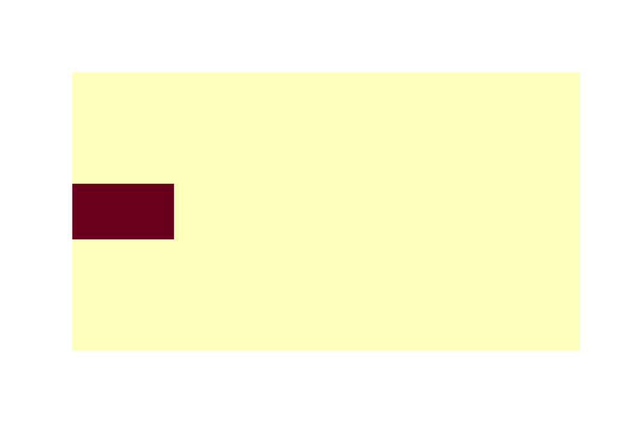

```
## [1] "Coordenada: 3,2"
```

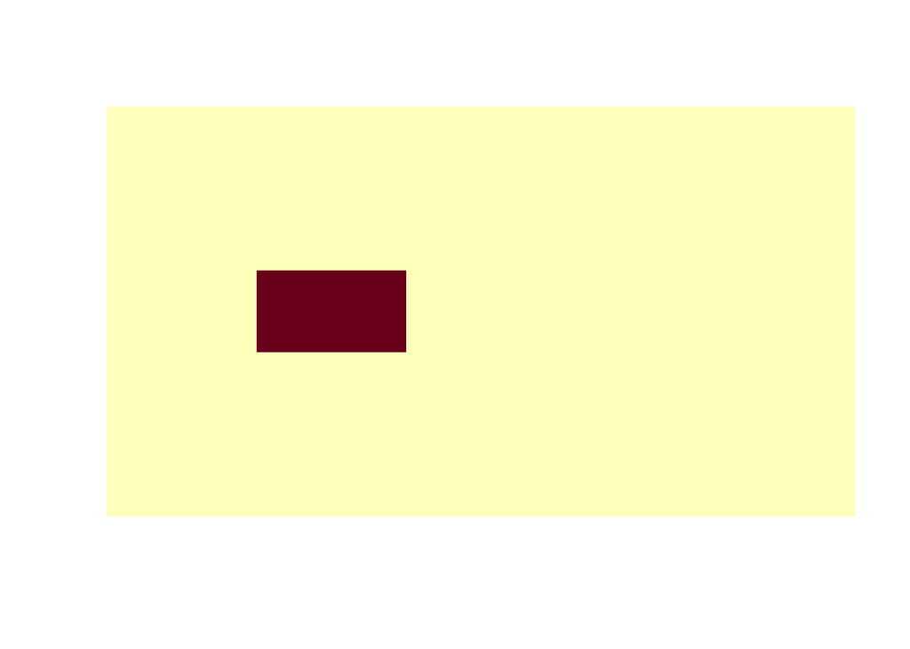

```
## [1] "Coordenada: 3,3"
```

[13 more figures not shown]

```r
# Iteraciones anidadas
for(fila in 1:nrow(matriz)){
  for(columna in 1:ncol(matriz)){
    matriz_temporal = matrix(0, ncol = 5, nrow = 5)
    matriz_temporal[fila,columna] = 1
    print(paste0('Coordenada: ', matriz[fila,columna]))
    image(t(apply(matriz_temporal,2,rev)),axes=FALSE)
    Sys.sleep(0.5)
    }
  }
```

```r
x = 0
while (x<=100) {
  print(x)
  x = x + 10
}
```

```
## [1] 0
## [1] 10
## [1] 20
## [1] 30
## [1] 40
## [1] 50
## [1] 60
## [1] 70
## [1] 80
## [1] 90
## [1] 100
```

##### Control de Flujos

El control de flujos nos permite incorporar condiciones cuando estamos operando con flujos

```r
x = 0
while (x<=100) {
  if(x < 50){
    print('Te falta mucho')
  } else if (x == 50){
    print('Ya vas a la mitad')
  } else if (x<100){
    print('Cada vez falta menos')
  } else{
    print('Llegaste al 100')
  }
  x = x + 10
}
```

```
## [1] "Te falta mucho"
## [1] "Te falta mucho"
## [1] "Te falta mucho"
## [1] "Te falta mucho"
## [1] "Te falta mucho"
## [1] "Ya vas a la mitad"
## [1] "Cada vez falta menos"
## [1] "Cada vez falta menos"
## [1] "Cada vez falta menos"
## [1] "Cada vez falta menos"
## [1] "Llegaste al 100"
```